# act_report

## Projet : Préparation et analyse des données

### *L’ensemble de données : l’archive de tweets de l’utilisateur de Twitter @dog_rates, également connu sous le nom de WeRateDogs.*

### Présentation :

- WeRateDogs est un compte Twitter qui évalue les chiens des gens avec un commentaire humoristique sur le chien.

### Analyse :

- Question 1- Quelle est la source la plus populaire sur notre dataset

```python
 Twitter for iPhone    1937
 Twitter Web Client      28
 TweetDeck               11
 Name: source, dtype: int64
```

*Ce code nous montre clairement que la majorité des tweets de l'archive weratesdog est tirée de Twitter pour Iphone, contrairement aux sources Twitter Web Client et TweetDeck qui sont moins utilisees*

- Question 2- Quelle sont stades de chiens les plus frequents

```python
pupper           203
doggo             63
puppo             22
doggo,pupper       9
floofer            7
doggo,puppo        1
doggo,floofer      1
Name: dog_stage, dtype: int64
```

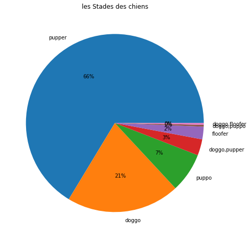

- Question 3- Quelle type de correlation existe entre le nombre de favoris et le nombre de retweet

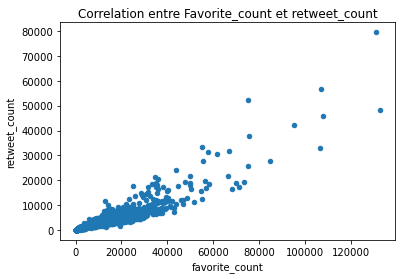

*Apparemment la correlation entre le nombre de favoris et le nombre de retweets est positive. Donc plus un chien a des retweets plus son nombre de favoris augmente. Mais surement il faudra trouver si ce type de correlation est toujours le meme pour d'autres variables du dataset en fonction du nombre de favoris car la prise en compte de plusieurs parametres reste plus precise.*

- Question 4- Quelle est la meilleure race de chien selon les predictions p1

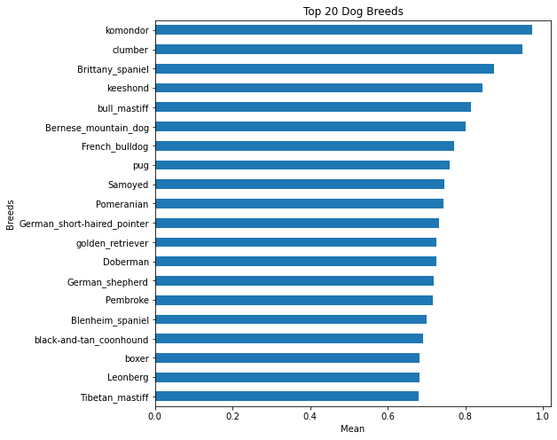

*Selon les predictions p1 apres avoir filtre les colonne ou on retrouve des chiens , c'est le Komondor qui est appurue comme meilleure race de chiens en fonction du degré de confiance et etroitement suivi par le dumber et le Britanny_spaniel*